# Analisis Kategori Film Paling Populer

Imelda Lovena M0724013

26 Mei 2026

## 1. Pendahuluan

> **Pertanyaan analisis:** Dari 16 kategori film yang tersedia dalam database Sakila, kategori manakah yang paling banyak disewa oleh pelanggan? Bagaimana distribusi permintaan antar genre secara keseluruhan?

Data diambil dari empat tabel dalam database Sakila melalui operasi `JOIN`. Hanya kolom yang relevan yang dipilih sehingga query tetap ringan dan efisien.

| Tabel | Peran dalam Analisis |
| --- | --- |
| `rental` | Sumber utama — setiap baris merepresentasikan satu transaksi sewa |
| `inventory` | Jembatan antara transaksi rental dan data film |
| `film_category` | Relasi antara film dengan kategori genre-nya |
| `category` | Nama dan ID dari setiap kategori genre |

## 2. Persiapan Data

```r
library(RMySQL)     # Koneksi ke MySQL
library(dplyr)      # Manipulasi dan transformasi data
library(ggplot2)    # Visualisasi data
library(scales)     # Format angka pada sumbu plot
```

Koneksi ke database dilakukan melalui `dbConnect()`. Pastikan MySQL server aktif dan database Sakila sudah diimport sebelum menjalankan bagian ini.

```r
con <- dbConnect(
  RMySQL::MySQL(),
  dbname   = "sakila",
  host     = "127.0.0.1",
  port     = 3306,
  user     = "root",
  password = "1318#lovena"
)
```

Query SQL berikut menghitung total penyewaan per kategori:

```r
query <- "
  SELECT
    c.name             AS kategori,
    COUNT(r.rental_id) AS total_sewa
  FROM rental r
    JOIN inventory     i   ON r.inventory_id  = i.inventory_id
    JOIN film_category fc  ON i.film_id        = fc.film_id
    JOIN category      c   ON fc.category_id   = c.category_id
  GROUP BY
    c.category_id,
    c.name
  ORDER BY
    total_sewa DESC;
"

df_raw <- dbGetQuery(con, query)
dbDisconnect(con)
```

Transformasi data dan penambahan metrik turunan:

```r
df <- df_raw |>
  arrange(desc(total_sewa)) |>
  mutate(
    rank      = row_number(),
    persen    = round(total_sewa / sum(total_sewa) * 100, 2),
    kumulatif = round(cumsum(total_sewa) / sum(total_sewa) * 100, 1),
    deviasi   = round(total_sewa - mean(total_sewa), 1),
    kategori  = factor(kategori, levels = rev(kategori)),
    tier      = case_when(
      rank <= 3  ~ "Top 3",
      rank <= 9  ~ "Atas Rata-rata",
      TRUE       ~ "Bawah Rata-rata"
    )
  )
```

Ringkasan metrik awal:

- **Total Kategori Genre**: 16
- **Total Transaksi Sewa**: 16.044
- **Rata-rata Sewa per Kategori**: 1.003
- **Selisih Tertinggi vs Terendah**: ~30%

## Persamaan Matematis

Total penyewaan pada kategori ke-$i$ dihitung sebagai:

$$T_i = \sum_{j=1}^{n} r_{ij}$$

dengan $T_i$ adalah total penyewaan kategori ke-$i$, sedangkan $r_{ij}$ menunjukkan transaksi rental ke-$j$ pada kategori tersebut.

Proporsi penyewaan kategori ke-$i$ terhadap seluruh kategori dihitung dengan:

$$P_i = \frac{T_i}{\sum_{i=1}^{k} T_i} \times 100\%$$

Persentase kumulatif dihitung sebagai:

$$K_i = \frac{\sum_{m=1}^{i} T_m}{\sum_{i=1}^{k} T_i} \times 100\%$$

Deviasi penyewaan kategori terhadap rata-rata dihitung dengan:

$$D_i = T_i - \bar{T}$$

Koefisien variasi digunakan untuk melihat tingkat keragaman distribusi penyewaan antar kategori:

$$CV = \frac{s}{\bar{T}} \times 100\%$$

## 3. Visualisasi Data

### Distribusi Penyewaan per Kategori

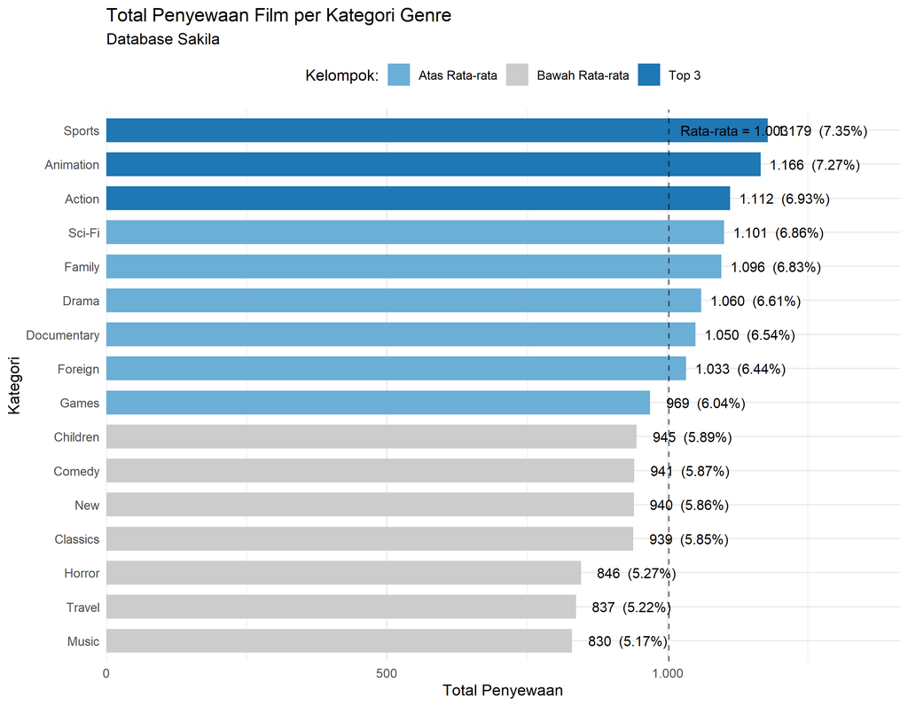

```r
pal <- c(
  "Top 3"            = "#1f77b4",
  "Atas Rata-rata"   = "#6baed6",
  "Bawah Rata-rata"  = "#cccccc"
)

rata2 <- mean(df_raw$total_sewa)

ggplot(df, aes(x = kategori, y = total_sewa, fill = tier)) +
  geom_col(width = 0.7) +
  geom_hline(yintercept = rata2, linetype = "dashed", color = "black", alpha = 0.6) +
  geom_text(
    aes(label = paste0(format(total_sewa, big.mark = "."), "  (", persen, "%)")),
    hjust = -0.1, size = 3.5
  ) +
  annotate("text", x = 16, y = rata2 + 20,
    label = paste0("Rata-rata = ", format(round(rata2), big.mark = ".")),
    hjust = 0, size = 3.5, color = "black"
  ) +
  scale_fill_manual(values = pal, name = "Kelompok:") +
  scale_y_continuous(
    expand = expansion(mult = c(0, 0.2)),
    labels = comma_format(big.mark = ".")
  ) +
  coord_flip() +
  labs(
    title = "Total Penyewaan Film per Kategori Genre",
    subtitle = "Database Sakila",
    x = "Kategori",
    y = "Total Penyewaan"
  ) +
  theme_minimal() +
  theme(legend.position = "top")
```

### Deviasi dari Rata-rata

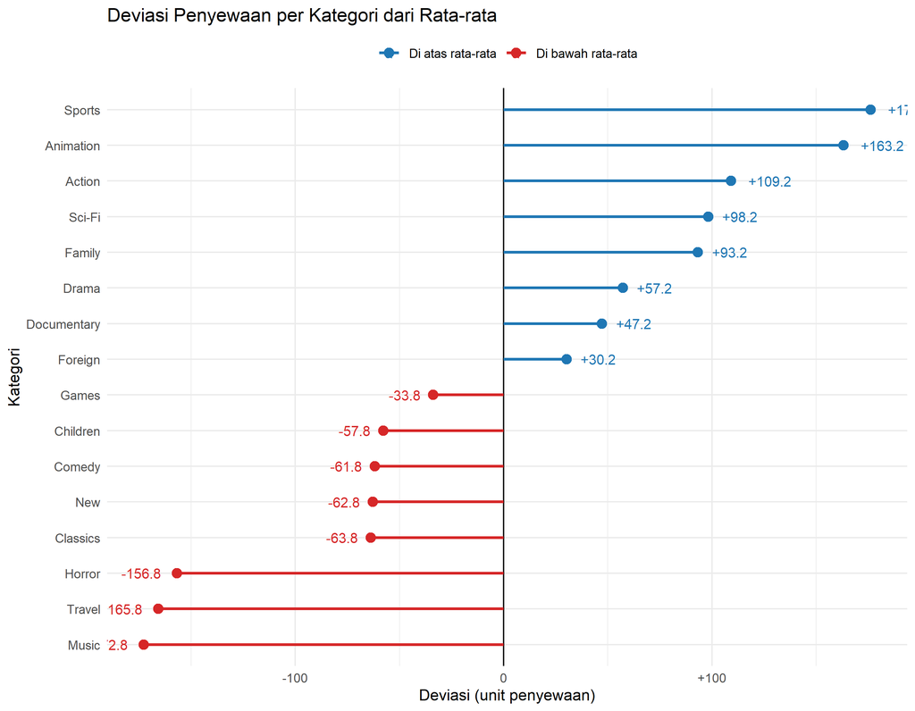

```r
ggplot(df, aes(x = kategori, y = deviasi,
               color = ifelse(deviasi >= 0, "atas", "bawah"))) +
  geom_hline(yintercept = 0, color = "black") +
  geom_segment(aes(xend = kategori, y = 0, yend = deviasi), linewidth = 1) +
  geom_point(size = 3) +
  geom_text(
    aes(
      label = paste0(ifelse(deviasi > 0, "+", ""), deviasi),
      hjust = ifelse(deviasi > 0, -0.4, 1.4)
    ),
    size = 3.5
  ) +
  scale_color_manual(
    values = c("atas" = "#1f77b4", "bawah" = "#d62728"),
    labels = c("atas" = "Di atas rata-rata", "bawah" = "Di bawah rata-rata"),
    name   = NULL
  ) +
  scale_y_continuous(
    labels = function(x) ifelse(x > 0, paste0("+", x), as.character(x))
  ) +
  coord_flip() +
  labs(
    title = "Deviasi Penyewaan per Kategori dari Rata-rata",
    x = "Kategori",
    y = "Deviasi (unit penyewaan)"
  ) +
  theme_minimal() +
  theme(legend.position = "top")
```

## 4. Tabel Ringkasan Data

```r
df_tabel <- df |>
  arrange(rank) |>
  transmute(
    Rank            = rank,
    Kategori        = as.character(kategori),
    `Total Sewa`    = format(total_sewa, big.mark = "."),
    `Proporsi (%)`  = paste0(persen, "%"),
    `Kumulatif (%)` = paste0(kumulatif, "%"),
    `Deviasi`       = paste0(ifelse(deviasi > 0, "+", ""), deviasi),
    Tier            = tier
  )

knitr::kable(
  df_tabel,
  align   = c("c","l","r","r","r","r","l"),
  caption = "Rangkuman Penyewaan Film per Kategori Genre"
)
```

Rangkuman Penyewaan Film per Kategori Genre

| Rank | Kategori | Total Sewa | Proporsi (%) | Kumulatif (%) | Deviasi | Tier |
| --- | --- | --- | --- | --- | --- | --- |
| 1 | Sports | 1.179 | 7.35% | 7.3% | +176.2 | Top 3 |
| 2 | Animation | 1.166 | 7.27% | 14.6% | +163.2 | Top 3 |
| 3 | Action | 1.112 | 6.93% | 21.5% | +109.2 | Top 3 |
| 4 | Sci-Fi | 1.101 | 6.86% | 28.4% | +98.2 | Atas Rata-rata |
| 5 | Family | 1.096 | 6.83% | 35.2% | +93.2 | Atas Rata-rata |
| 6 | Drama | 1.060 | 6.61% | 41.8% | +57.2 | Atas Rata-rata |
| 7 | Documentary | 1.050 | 6.54% | 48.4% | +47.2 | Atas Rata-rata |
| 8 | Foreign | 1.033 | 6.44% | 54.8% | +30.2 | Atas Rata-rata |
| 9 | Games | 969 | 6.04% | 60.9% | -33.8 | Atas Rata-rata |
| 10 | Children | 945 | 5.89% | 66.8% | -57.8 | Bawah Rata-rata |
| 11 | Comedy | 941 | 5.87% | 72.6% | -61.8 | Bawah Rata-rata |
| 12 | New | 940 | 5.86% | 78.5% | -62.8 | Bawah Rata-rata |
| 13 | Classics | 939 | 5.85% | 84.3% | -63.8 | Bawah Rata-rata |
| 14 | Horror | 846 | 5.27% | 89.6% | -156.8 | Bawah Rata-rata |
| 15 | Travel | 837 | 5.22% | 94.8% | -165.8 | Bawah Rata-rata |
| 16 | Music | 830 | 5.17% | 100% | -172.8 | Bawah Rata-rata |

## 5. Analisis Statistik

Rata-rata jumlah penyewaan dari seluruh kategori adalah sekitar 1.003 penyewaan.

Koefisien variasi (CV) digunakan untuk mengukur seberapa merata distribusi permintaan antar kategori. Nilai CV yang rendah (< 15%) mengindikasikan bahwa distribusi permintaan antar kategori cukup merata, tidak ada dominasi ekstrem dari satu genre tertentu.

```r
stat_tabel <- df_raw |>
  summarise(
    `Jumlah Kategori`  = n(),
    `Total Sewa`       = sum(total_sewa),
    `Rata-rata`        = round(mean(total_sewa), 2),
    `Median`           = median(total_sewa),
    `Std. Deviasi`     = round(sd(total_sewa), 2),
    `CV (%)`           = round(sd(total_sewa) / mean(total_sewa) * 100, 2),
    `Min`              = min(total_sewa),
    `Max`              = max(total_sewa)
  )

knitr::kable(
  t(stat_tabel),
  col.names = c("Nilai"),
  caption   = "Statistik Deskriptif Jumlah Penyewaan"
)
```

Statistik Deskriptif Jumlah Penyewaan

|  | Nilai |
| --- | --- |
| Jumlah Kategori | 16.00 |
| Total Sewa | 16044.00 |
| Rata-rata | 1002.75 |
| Median | 1001.00 |
| Std. Deviasi | 113.31 |
| CV (%) | 11.30 |
| Min | 830.00 |
| Max | 1179.00 |

## 6. Interpretasi Hasil

Berdasarkan analisis visualisasi dan statistik deskriptif di atas, diperoleh beberapa temuan: